# Topic: At the same age, are younger generations less likely to own homes than previous generations?

## Exploratory Data Analysis (EDA) code:

```python
import pandas as pd
import numpy as np

df = pd.read_csv("regression.csv")
```

```python
df.tail()
```

|  | YEAR | OWNERSHP | OWNERSHPD | PERWT | AGE | MARST | EDUC | EDUCD | EMPSTAT | EMPSTATD | INCTOT | 30 year fixed rate | MSPUS |
| --- | --- | --- | --- | --- | --- | --- | --- | --- | --- | --- | --- | --- | --- |
| 1070052 | 2024 | 1 | 12 | 63.0 | 48 | 5 | 6 | 63 | 1 | 10 | 42000 | 6.721154 | 418975.0 |
| 1070053 | 2024 | 1 | 13 | 89.0 | 64 | 1 | 6 | 65 | 3 | 30 | 27000 | 6.721154 | 418975.0 |
| 1070054 | 2024 | 2 | 22 | 65.0 | 39 | 4 | 11 | 114 | 1 | 10 | 80300 | 6.721154 | 418975.0 |
| 1070055 | 2024 | 1 | 13 | 130.0 | 15 | 6 | 2 | 26 | 0 | 0 | 1200 | 6.721154 | 418975.0 |
| 1070056 | 2024 | 1 | 12 | 96.0 | 66 | 1 | 10 | 101 | 3 | 30 | 53400 | 6.721154 | 418975.0 |

```python
df = df.rename(columns={'30 year fixed rate':'fixed_rate_30'})
```

```python
# 0 means missing or not applicable, so I excluded it in my analysis.
df = df[df['OWNERSHP']!=0]

df['Ownership_Status'] = df['OWNERSHP'].map({1:1,2:0})
```

```python
# For better interpretability
def marst_group(x):
    if x in [1, 2]:
        return 'Married'
    elif x in [3, 4]:
        return 'Separated/Divorced'
    elif x == 5:
        return 'Widowed'
    elif x == 6:
        return 'Never married'
```

```python
df['Marital_Status'] = df.MARST.apply(lambda x : marst_group(x))
```

```python
# For better interpretability
def degree(x):
    if x < 101:
        return "No college Degree"
    elif 101 <= x <=113:
        return "Bachelors Degree"
    elif 114 <= x <=116:
        return "Degrees beyond a bachelors degree"
    else:
        return "Missing"
```

```python
df['Degree'] = df.EDUCD.apply(lambda x : degree(x))
```

```python
# For better interpretability
def employment(x):
    if x ==0:
        return "N/A"
    elif x ==1:
        return "Employed"
    elif x ==2:
        return "Unemployed"
    elif x == 3:
        return "Not in labor force"
    else:
        return "Unknown"
```

```python
df['Employement_Status'] = df.EMPSTAT.apply(lambda x : employment(x))
```

```python
df['birth_year'] = df['YEAR'] - df['AGE']
```

```python
# To classify their generations
def generation(x):
    if 1946 <= x <= 1964:
        return 'Boomers'
    elif 1965 <= x <= 1980:
        return 'Gen X'
    elif 1981 <= x <= 1996:
        return 'Millennials'
    elif 1997 <= x <= 2012:
        return 'Gen Z'
    elif x > 2012:
        return 'Gen Alpha'
    else:
        return 'Pre-Boomer'
```

```python
df['Generation_Category'] = df['birth_year'].apply(lambda x : generation(x))
```

```python
#According to the IPUMS, these numbers are specific variable codes, which stand for N/A.
# To reduce further confusion, I decided to drop them
df = df[~df['INCTOT'].isin([9999999, 999998])]
```

```python
df.head()
```

|  | YEAR | OWNERSHP | OWNERSHPD | PERWT | AGE | MARST | EDUC | EDUCD | EMPSTAT | EMPSTATD | INCTOT | fixed_rate_30 | MSPUS | Ownership_Status | Marital_Status | Degree | Employement_Status | birth_year | Generation_Category |
| --- | --- | --- | --- | --- | --- | --- | --- | --- | --- | --- | --- | --- | --- | --- | --- | --- | --- | --- | --- |
| 0 | 1970 | 1 | 10 | 100.0 | 45 | 6 | 6 | 60 | 1 | 10 | 9050 | NaN | NaN | 1 | Never married | No college Degree | Employed | 1925 | Pre-Boomer |
| 2 | 1970 | 1 | 10 | 100.0 | 70 | 5 | 2 | 26 | 3 | 30 | 0 | NaN | NaN | 1 | Widowed | No college Degree | Not in labor force | 1900 | Pre-Boomer |
| 3 | 1970 | 1 | 10 | 100.0 | 46 | 1 | 6 | 60 | 3 | 30 | 0 | NaN | NaN | 1 | Married | No college Degree | Not in labor force | 1924 | Pre-Boomer |
| 6 | 1970 | 2 | 22 | 100.0 | 74 | 5 | 1 | 17 | 3 | 30 | 450 | NaN | NaN | 0 | Widowed | No college Degree | Not in labor force | 1896 | Pre-Boomer |
| 7 | 1970 | 2 | 22 | 100.0 | 19 | 6 | 1 | 16 | 3 | 30 | 1950 | NaN | NaN | 0 | Never married | No college Degree | Not in labor force | 1951 | Boomers |

```python
# Drop original variables to avoid redundancy and multicollinearity after feature engineering
df = df.drop(['OWNERSHP','OWNERSHPD','MARST','EDUC','EDUCD','EMPSTAT','EMPSTATD'],axis=1)
```

```python
# the dataset has no interest rate and MSPUS for 1970, so I decided to drop it.
df = df[df['YEAR']!=1970]
# only adults
df = df[df['AGE']>=18]
```

```python
df['age_group'] = pd.cut(df['AGE'], bins=[0, 25, 35, 45, 55, 65, 100],labels=['18-25', '26-35', '36-45', '46-55', '56-65', '65+'])
```

**Interpretation**

```python
import cpi
#taking inflation into account
years = df['YEAR'].unique()

cpi_factors = {
    year: cpi.inflate(1, year, to=2024)
    for year in years
}


df['cpi_factor'] = df['YEAR'].map(cpi_factors)


df['adjusted_INCTOT'] = df['INCTOT'] * df['cpi_factor']
df['adjusted_MSPUS'] = df['MSPUS'] * df['cpi_factor']
```

```python
df.groupby('YEAR')[['adjusted_MSPUS', 'adjusted_INCTOT']].mean()
```

| YEAR | adjusted_MSPUS | adjusted_INCTOT |
| --- | --- | --- |
| 1980 | 246497.120752 | 38399.715205 |
| 1990 | 293528.421576 | 45128.174165 |
| 2000 | 305218.304007 | 53432.099675 |
| 2001 | 306603.985884 | 54411.306459 |
| 2002 | 324369.072957 | 55686.248128 |
| 2003 | 327540.756114 | 53923.250413 |
| 2004 | 362261.807041 | 54441.487178 |
| 2005 | 379944.357143 | 54677.507370 |
| 2006 | 379274.274554 | 54109.036805 |
| 2007 | 370586.376856 | 56737.939602 |
| 2008 | 334446.384630 | 55629.249322 |
| 2009 | 315316.392277 | 55000.636718 |
| 2010 | 320369.722915 | 53029.806307 |
| 2011 | 313634.612495 | 50454.487204 |
| 2012 | 333918.097163 | 52136.543124 |
| 2013 | 358486.132741 | 53747.087936 |
| 2014 | 378668.533620 | 53694.027618 |
| 2015 | 389303.802470 | 56179.820517 |
| 2016 | 398798.185574 | 57169.723626 |
| 2017 | 412619.026701 | 57879.239845 |
| 2018 | 406341.477836 | 57276.388444 |
| 2019 | 392944.070571 | 60865.683449 |
| 2020 | 397730.565355 | 62090.401783 |
| 2021 | 443380.769089 | 59175.412415 |
| 2022 | 464067.425979 | 58433.947620 |
| 2023 | 439105.095224 | 59939.016675 |
| 2024 | 418975.000000 | 59604.903889 |

```python
df.groupby('Generation_Category')['adjusted_INCTOT'].median()
```

```
Generation_Category
Boomers        40801.170620
Gen X          40258.576655
Gen Z          10294.943912
Millennials    26661.753886
Pre-Boomer     28800.826320
Name: adjusted_INCTOT, dtype: float64
```

```python
df.groupby('Generation_Category')['INCTOT'].median()
```

```
Generation_Category
Boomers        24000.0
Gen X          27000.0
Gen Z           9000.0
Millennials    20000.0
Pre-Boomer     14800.0
Name: INCTOT, dtype: float64
```

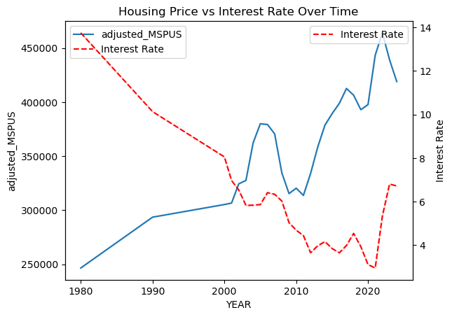

```python
import seaborn as sns
import matplotlib.pyplot as plt

#Relationships between housing and interest rate
fig, ax1 = plt.subplots()


line1 = sns.lineplot(x='YEAR', y='adjusted_MSPUS', data=df, ax=ax1, label='adjusted_MSPUS')
ax1.set_ylabel('adjusted_MSPUS')


ax2 = ax1.twinx()

line2 = sns.lineplot(
    x='YEAR',
    y='fixed_rate_30',
    data=df,
    ax=ax2,
    linestyle='--',
    color='red',
    label='Interest Rate'
)
ax2.set_ylabel('Interest Rate')


lines = ax1.get_lines() + ax2.get_lines()
labels = [l.get_label() for l in lines]

ax1.legend(lines, labels, loc='upper left')

plt.title('Housing Price vs Interest Rate Over Time')
plt.show()
```

```python
#Percentage of owning homes by age groups and generations
diff = (df.groupby(['Generation_Category','age_group'], observed=True)
    .apply(lambda x: (x.loc[x['Ownership_Status']==1, 'PERWT'].sum()) / x['PERWT'].sum(),
         include_groups=False).reset_index(name='Percentage of owning homes'))
diff
```

|  | Generation_Category | age_group | Percentage of owning homes |
| --- | --- | --- | --- |
| 0 | Boomers | 18-25 | 0.534359 |
| 1 | Boomers | 26-35 | 0.593714 |
| 2 | Boomers | 36-45 | 0.733091 |
| 3 | Boomers | 46-55 | 0.775682 |
| 4 | Boomers | 56-65 | 0.797878 |
| 5 | Boomers | 65+ | 0.826084 |
| 6 | Gen X | 18-25 | 0.445548 |
| 7 | Gen X | 26-35 | 0.556802 |
| 8 | Gen X | 36-45 | 0.665412 |
| 9 | Gen X | 46-55 | 0.732306 |
| 10 | Gen X | 56-65 | 0.783636 |
| 11 | Gen Z | 18-25 | 0.538410 |
| 12 | Gen Z | 26-35 | 0.514367 |
| 13 | Millennials | 18-25 | 0.504417 |
| 14 | Millennials | 26-35 | 0.513435 |
| 15 | Millennials | 36-45 | 0.649726 |
| 16 | Pre-Boomer | 26-35 | 0.726106 |
| 17 | Pre-Boomer | 36-45 | 0.774966 |
| 18 | Pre-Boomer | 46-55 | 0.808135 |
| 19 | Pre-Boomer | 56-65 | 0.837648 |
| 20 | Pre-Boomer | 65+ | 0.809298 |

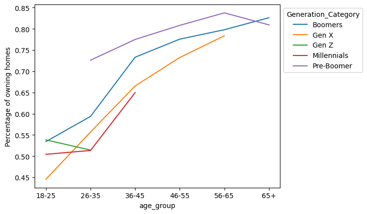

```python
#Percentage of owning homes by age groups and generations
sns.lineplot(x='age_group',y='Percentage of owning homes',hue='Generation_Category',data=diff)
plt.legend(bbox_to_anchor=(1,1),title='Generation_Category')
plt.show()
```

**Interpretation**

```python
df['age_centered'] = df['AGE'] - df['AGE'].mean()
df['age_c2'] = df['age_centered']**2

df["PERWT_norm"] = df["PERWT"] / df["PERWT"].sum() * len(df)
df = df[df['PERWT_norm']>0]
```

```python
df.head()
df = df.drop(['INCTOT','MSPUS','birth_year','cpi_factor'],axis=1)
```

```python
import statsmodels.api as sm
import statsmodels.formula.api as smf
import numpy as np


np.random.seed(123)
# split data into train/test
test_rows = np.random.choice(df.index, size=int(0.2 * len(df)), replace=False)

testData = df.loc[test_rows].reset_index(drop=True)
trainData = df.drop(test_rows).reset_index(drop=True)


#include all predictors
predictors = "+".join([
    col for col in trainData.columns
    if col not in ["Ownership_Status", "PERWT_norm"]
])
formula = f"Ownership_Status ~ {predictors}"


model_weight = smf.glm(
    formula=formula, data=trainData,
    family=sm.families.Binomial(),
    var_weights=trainData["PERWT_norm"]
).fit(cov_type='cluster', cov_kwds={'groups': trainData['YEAR']})

print(model_weight.summary())
```

```
                 Generalized Linear Model Regression Results
==============================================================================
Dep. Variable:       Ownership_Status   No. Observations:               616060
Model:                            GLM   Df Residuals:                   616036
Model Family:                Binomial   Df Model:                           23
Link Function:                  Logit   Scale:                          1.0000
Method:                          IRLS   Log-Likelihood:            -3.3866e+05
Date:                Sun, 26 Apr 2026   Deviance:                   6.7733e+05
Time:                        13:07:35   Pearson chi2:                 6.30e+05
No. Iterations:                     6   Pseudo R-squ. (CS):             0.1345
Covariance Type:              cluster
===============================================================================================================
                                                  coef    std err          z      P>|z|      [0.025      0.975]
---------------------------------------------------------------------------------------------------------------
Intercept                                       0.0157        nan        nan        nan         nan         nan
Marital_Status[T.Never married]                -0.8481      0.015    -57.476      0.000      -0.877      -0.819
Marital_Status[T.Separated/Divorced]           -1.1134      0.032    -35.240      0.000      -1.175      -1.051
Marital_Status[T.Widowed]                      -0.8228      0.053    -15.419      0.000      -0.927      -0.718
Degree[T.Degrees beyond a bachelors degree]    -0.0110      0.059     -0.186      0.852      -0.127       0.105
Degree[T.No college Degree]                    -0.1954      0.033     -5.898      0.000      -0.260      -0.130
Employement_Status[T.Not in labor force]        0.0113      0.014      0.832      0.405      -0.015       0.038
Employement_Status[T.Unemployed]               -0.0894      0.030     -2.987      0.003      -0.148      -0.031
Generation_Category[T.Gen X]                   -0.2196      0.028     -7.804      0.000      -0.275      -0.164
Generation_Category[T.Gen Z]                    0.0813      0.126      0.643      0.520      -0.167       0.329
Generation_Category[T.Millennials]             -0.2097      0.068     -3.105      0.002      -0.342      -0.077
Generation_Category[T.Pre-Boomer]               0.1076      0.049      2.191      0.028       0.011       0.204
age_group[T.26-35]                             -0.2478      0.034     -7.351      0.000      -0.314      -0.182
age_group[T.36-45]                              0.2265      0.054      4.213      0.000       0.121       0.332
age_group[T.46-55]                              0.5724      0.067      8.545      0.000       0.441       0.704
age_group[T.56-65]                              0.8201      0.081     10.149      0.000       0.662       0.978
age_group[T.65+]                                0.9706      0.092     10.515      0.000       0.790       1.151
YEAR                                           -0.0084      0.008     -1.020      0.308      -0.025       0.008
PERWT                                          -0.0014      0.000    -11.672      0.000      -0.002      -0.001
AGE                                             0.3750        nan        nan        nan         nan         nan
fixed_rate_30                                  -0.0276      0.021     -1.335      0.182      -0.068       0.013
adjusted_INCTOT                              4.749e-06   2.18e-07     21.790      0.000    4.32e-06    5.18e-06
adjusted_MSPUS                               7.664e-07   8.47e-07      0.904      0.366   -8.94e-07    2.43e-06
age_centered                                   -0.3791        nan        nan        nan         nan         nan
age_c2                                      -2.554e-05   4.56e-05     -0.560      0.576      -0.000    6.39e-05
===============================================================================================================
```

# Variable Selection

```python
import warnings
from statsmodels.tools.sm_exceptions import PerfectSeparationWarning


# YEAR was excluded as a predictor and used for clustering
# # PERWT is used as sampling weights, not as a predictor
variables = [
    'C(Marital_Status)', 'C(Degree)', 'C(Employement_Status)',
    'C(Generation_Category)', 'age_centered', 'age_c2',
    'adjusted_INCTOT', 'fixed_rate_30', 'adjusted_MSPUS'
]

selected = []
remaining = variables.copy()
aic_trace = []
current_aic = float('inf')
best_model = None

def fit_glm(predictors):
    formula = 'Ownership_Status ~ ' + ' + '.join(predictors)
    return smf.glm(
        formula=formula,
        data=trainData,
        family=sm.families.Binomial(),
        var_weights=trainData['PERWT_norm']
    ).fit()

while remaining:
    results = []

    for var in remaining:
        model = fit_glm(selected + [var])
        results.append((model.aic, var, model))

    best_aic, best_var, best_fit = min(results, key=lambda x: x[0])

    if best_aic >= current_aic:
        break

    selected.append(best_var)
    remaining.remove(best_var)
    current_aic = best_aic
    best_model = best_fit
    aic_trace.append((len(selected), best_aic, best_var))

    print(f"Step {len(selected):2d}: + '{best_var:<35s}'  AIC = {best_aic:.2f}")
```

```
Step  1: + 'C(Marital_Status)                  '  AIC = 717849.34
Step  2: + 'age_centered                       '  AIC = 699756.82
Step  3: + 'adjusted_INCTOT                    '  AIC = 692048.61
Step  4: + 'C(Generation_Category)             '  AIC = 689061.56
Step  5: + 'C(Degree)                          '  AIC = 688373.28
Step  6: + 'C(Employement_Status)              '  AIC = 688330.39
Step  7: + 'age_c2                             '  AIC = 688283.45
```

**Interpretation**

Only seven out of nine variables were retained by the forward selection procedure.

```python
model_weight_variable_section = smf.glm(
    'Ownership_Status ~ age_centered + age_c2 + adjusted_INCTOT  + C(Marital_Status) + C(Degree) + C(Employement_Status) + C(Generation_Category)',data=trainData,
    family=sm.families.Binomial(),
    var_weights=trainData["PERWT_norm"]
).fit(cov_type='cluster', cov_kwds={'groups': trainData['YEAR']})

print(model_weight_variable_section.summary())
```

```
                 Generalized Linear Model Regression Results
==============================================================================
Dep. Variable:       Ownership_Status   No. Observations:               616060
Model:                            GLM   Df Residuals:                   616045
Model Family:                Binomial   Df Model:                           14
Link Function:                  Logit   Scale:                          1.0000
Method:                          IRLS   Log-Likelihood:            -3.4413e+05
Date:                Sun, 26 Apr 2026   Deviance:                   6.8825e+05
Time:                        13:12:11   Pearson chi2:                 6.24e+05
No. Iterations:                     6   Pseudo R-squ. (CS):             0.1190
Covariance Type:              cluster
==================================================================================================================
                                                     coef    std err          z      P>|z|      [0.025      0.975]
------------------------------------------------------------------------------------------------------------------
Intercept                                          1.4399      0.036     39.995      0.000       1.369       1.510
C(Marital_Status)[T.Never married]                -0.8127      0.021    -37.976      0.000      -0.855      -0.771
C(Marital_Status)[T.Separated/Divorced]           -1.1164      0.016    -67.966      0.000      -1.149      -1.084
C(Marital_Status)[T.Widowed]                      -0.8911      0.023    -38.907      0.000      -0.936      -0.846
C(Degree)[T.Degrees beyond a bachelors degree]    -0.0003      0.018     -0.018      0.986      -0.036       0.036
C(Degree)[T.No college Degree]                    -0.1895      0.017    -11.338      0.000      -0.222      -0.157
C(Employement_Status)[T.Not in labor force]        0.0241      0.012      1.943      0.052      -0.000       0.048
C(Employement_Status)[T.Unemployed]               -0.0826      0.030     -2.761      0.006      -0.141      -0.024
C(Generation_Category)[T.Gen X]                   -0.4088      0.050     -8.145      0.000      -0.507      -0.310
C(Generation_Category)[T.Gen Z]                    0.0891      0.082      1.093      0.274      -0.071       0.249
C(Generation_Category)[T.Millennials]             -0.3854      0.065     -5.967      0.000      -0.512      -0.259
C(Generation_Category)[T.Pre-Boomer]               0.0767      0.038      2.032      0.042       0.003       0.151
age_centered                                       0.0183      0.001     12.993      0.000       0.016       0.021
age_c2                                         -8.515e-05    4.1e-05     -2.077      0.038      -0.000   -4.78e-06
adjusted_INCTOT                                 4.614e-06   2.07e-07     22.304      0.000    4.21e-06    5.02e-06
==================================================================================================================
```

```python
from scipy.stats import chi2

# Full model: includes Generation_Category
full_model = smf.glm(
    'Ownership_Status ~ age_centered + age_c2 + adjusted_INCTOT '
    '+ C(Marital_Status) + C(Degree) + C(Employement_Status) '
    '+ C(Generation_Category)',
    data=trainData,
    family=sm.families.Binomial(),
    var_weights=trainData['PERWT_norm']
).fit()

# Reduced model: without Generation_Category
reduced_model = smf.glm(
    'Ownership_Status ~ age_centered + age_c2 + adjusted_INCTOT '
    '+ C(Marital_Status) + C(Degree) + C(Employement_Status)',
    data=trainData,
    family=sm.families.Binomial(),
    var_weights=trainData['PERWT_norm']
).fit()

lr_stat = reduced_model.deviance - full_model.deviance
df_c = reduced_model.df_resid - full_model.df_resid
p_value = 1 - chi2.cdf(lr_stat, df_c)

print("Generation LRT")
print("LR statistic:", lr_stat)
print("df:", df_c)
print("p-value:", p_value)
```

```
Generation LRT
LR statistic: 3239.1517844548216
df: 4
p-value: 0.0
```

**Interpretation**

The p-value is 0.0, which is less than 0.05. Therefore, we reject the null hypothesis and conclude that Generation_Category is statistically significant predictor of the homeowner_status. This indicates that generation category significantly improves model fit after controlling for age, income, marital status, education, and employment status.

```python
#Checking if full model fits better than an intercept only model

full_model = model_weight_variable_section

null_model = smf.glm(
    'Ownership_Status ~ 1',
    data=trainData,
    family=sm.families.Binomial(),
    var_weights=trainData['PERWT_norm']
).fit()


LR_stat = 2 * (full_model.llf - null_model.llf)
df_diff = full_model.df_model - null_model.df_model
p_value = chi2.sf(LR_stat, df_diff)

print("LR statistic:", LR_stat)
print("Degrees of freedom:", df_diff)
print("p-value:", p_value)
```

```
LR statistic: 78057.98492428893
Degrees of freedom: 14
p-value: 0.0
```

**Interpretation**

Since the p-value is less than 0.05, we reject the null hypothesis that all coefficients are equal to zero, and conclude that the model is statistically significant overall and provides a significantly better fit than the model with no predictors.

# Statistical analysis and hypothesis testing

**Marital Status**

If the Marital_Status is Never married, the log odds of owning a home decreases by 0.8127 as compared to when the individual is married and the odds of owning a home change by a factor of exp(-0.8127) = 0.44 as compared to when the individual is married, holding all other variables constant.

If the Marital_Status is Separated/Divorced, the log odds of owning a home decreases by 1.1164 as compared to when the individual is married and the odds of owning a home change by a factor of exp(-1.1164) = 0.33 as compared to when the individual is married, holding all other variables constant.

If the Marital_Status is Widowed, the log odds of owning a home decreases by 0.8911 as compared to when the individual is married and the odds of owning a home change by a factor of exp(-0.8911) = 0.41 as compared to when the individual is married, holding all other variables constant.

Null hypothesis: H0: Marital Status=0

Alternative hypothesis: HA: Marital Status!=0

Since the p-values for all Marital_Status categories are less than 0.05, we reject the null hypothesis that marital status has no effect on homeownership. This indicates that marital status has a statistically significant effect on homeownership.

**Income**

For a one-unit increase in adjusted_INCTOT, the log odds of owning a home increases by 4.614e-06 and the odds of owning a home increase by exp(4.614e-06) ≈ 1.000006, holding all other variables constant.

Null hypothesis: H0: Income=0

Alternative hypothesis: HA: Income!=0

Since the p-value for INCTOT is less than 0.05, we reject the null hypothesis that income has no effect on homeownership. This suggests that income is a statistically significant predictor of homeownership.

**Education**

If the Degree is No college Degree, the log odds of owning a home decreases by 0.1895 as compared to when the individual has a bachelor’s degree (baseline) and the odds of owning a home change by a factor of exp(-0.1895) = 0.83 as compared to the baseline, holding all other variables constant.

If the Degree is Degrees beyond a bachelor’s degree, the log odds of owning a home decreases by 0.0003 as compared to the baseline and the odds of owning a home change by a factor of exp(-0.0003) ≈ 1.00 as compared to the baseline, holding all other variables constant.

Null hypothesis: H0: Education=0

Alternative hypothesis: HA: Education!=0

Since the p-value for individuals with no college degree is less than 0.05, we reject the null hypothesis that education has no effect on homeownership. This indicates that lacking a college degree significantly affects homeownership.

**Employment Status**

If the Employment_Status is Unemployed, the log odds of owning a home decreases by 0.0826 as compared to when the individual is employed and the odds of owning a home change by a factor of exp(-0.0826) = 0.92 as compared to when the individual is employed, holding all other variables constant.

If the Employment_Status is Not in labor force, the log odds of owning a home increases by 0.0241 as compared to when the individual is employed and the odds of owning a home change by a factor of exp(0.0241) = 1.02 as compared to when the individual is employed, holding all other variables constant.

Null hypothesis: H0: Employment Status=0

Alternative hypothesis: HA: Employment Status!=0

Since the p-value for the Unemployed category is less than 0.05, we reject the null hypothesis that employment status has no effect on homeownership. This indicates that being unemployed significantly affects homeownership likelihood.

**Generation Category**

If the Generation_Category is Gen X, the log odds of owning a home decreases by 0.4088 as compared to the baseline generation_Boomer and the odds of owning a home change by a factor of exp(-0.4088) = 0.66 as compared to the baseline, holding all other variables constant.

If the Generation_Category is Millennials, the log odds of owning a home decreases by 0.3854 as compared to the baseline generation_Boomer and the odds of owning a home change by a factor of exp(-0.3854) = 0.68 as compared to the baseline, holding all other variables constant.

If the Generation_Category is Gen Z, the log odds of owning a home increases by 0.0891 as compared to the baseline generation_Boomer and the odds of owning a home change by a factor of exp(0.0891) = 1.09 as compared to the baseline, holding all other variables constant. //The positive Gen Z coefficient should be interpreted carefully. Gen Z's presence in the sample is limited to early adulthood, and the observed effect likely reflects selection bias.//

If the Generation_Category is Pre-Boomer, the log odds of owning a home increases by 0.0767 as compared to the baseline generation_Boomer and the odds of owning a home change by a factor of exp(0.0767) = 1.08 as compared to the baseline, holding all other variables constant.

Null hypothesis: H0: Generation Category=0

Alternative hypothesis: HA: Generation Category!=0

Since the p-values for Gen X and Millennials are less than 0.05, we reject the null hypothesis that these generational categories have no effect on homeownership. This suggests that these generations differ significantly from the baseline group.

**Age (Nonlinear Effect)**

For a one-unit increase in age_centered, the log odds of owning a home increases by 0.0183 and the odds of owning a home increase by exp(0.0183) = 1.02, holding all other variables constant.

For a one-unit increase in age_c2, the log odds of owning a home decreases by 8.515e-05 and the odds of owning a home change by a factor of exp(-8.515e-05) ≈ 0.9999, holding all other variables constant.

Null hypothesis: H0: Age=0

Alternative hypothesis: HA: Age!=0

Since the p-values for both age_centered and age_c2 are less than 0.05, we reject the null hypothesis that age has no effect on homeownership. This indicates that age has a statistically significant nonlinear effect on homeownership.

# Goodness of Fit testing and model assumption checks // Outlier screening and handling procedures

```python
from scipy.stats import chi2

deviance = model_weight_variable_section.deviance
df_resid = model_weight_variable_section.df_resid

p_value = chi2.sf(deviance, df_resid)

print("Deviance:", deviance)
print("DF Residual:", df_resid)
print("GOF p-value:", p_value)
```

```
Deviance: 688253.4526076193
DF Residual: 616045
GOF p-value: 0.0
```

```python
pearson_chi2 = model_weight_variable_section.pearson_chi2
df_resid = model_weight_variable_section.df_resid

p_value = chi2.sf(pearson_chi2, df_resid)

print("Pearson Chi2:", pearson_chi2)
print("p-value:", p_value)
```

```
Pearson Chi2: 623721.4552349063
p-value: 2.8323917021116067e-12
```

**Interpretation** Null Hypothesis: H0: The model is a good fit

Alternative Hypothesis: HA: The model is not a good fit

A goodness-of-fit test was conducted using both deviance and Pearson chi-square tests. Since both p values are less than 0.05, we reject the null hypothesis and conclude that the model is not a good fit.

```python
print(f"Dispersion estimate (Pearson chi2 / df): {pearson_chi2 / df_resid:.4f}")
```

```
Dispersion estimate (Pearson chi2 / df): 1.0125
```

**Interpretation** Since the dispersion estimate is close to 1, there is no evidence of overdispersion, indicating that the variance is appropriately specified.

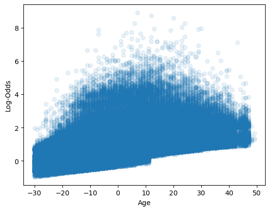

```python
p = model_weight_variable_section.predict(trainData)
logit_p = np.log(p / (1 - p))

plt.scatter(trainData['age_centered'], logit_p, alpha=0.1)
plt.xlabel("Age")
plt.ylabel("Log-Odds")
plt.show()
```

**Interpretation**

The relationship between age and the log-odds of homeownership appears approximately linear, although some dispersion is observed. This suggests that the linearity assumption is reasonably satisfied, with minor deviations likely due to interactions with other predictors.

```python
from statsmodels.stats.outliers_influence import variance_inflation_factor
X = model_weight_variable_section.model.exog
names = model_weight_variable_section.model.exog_names

vif_df=pd.DataFrame()
vif_df['variable']=names
vif_df['VIF']=[variance_inflation_factor(X,i) for i in range(X.shape[1])]
vif_df
```

|  | variable | VIF |
| --- | --- | --- |
| 0 | Intercept | 11.130489 |
| 1 | C(Marital_Status)[T.Never married] | 1.551483 |
| 2 | C(Marital_Status)[T.Separated/Divorced] | 1.074426 |
| 3 | C(Marital_Status)[T.Widowed] | 1.303080 |
| 4 | C(Degree)[T.Degrees beyond a bachelors degree] | 1.460921 |
| 5 | C(Degree)[T.No college Degree] | 1.539933 |
| 6 | C(Employement_Status)[T.Not in labor force] | 1.549263 |
| 7 | C(Employement_Status)[T.Unemployed] | 1.045127 |
| 8 | C(Generation_Category)[T.Gen X] | 1.438707 |
| 9 | C(Generation_Category)[T.Gen Z] | 1.281597 |
| 10 | C(Generation_Category)[T.Millennials] | 1.775517 |
| 11 | C(Generation_Category)[T.Pre-Boomer] | 1.832796 |
| 12 | age_centered | 3.017904 |
| 13 | age_c2 | 1.634386 |
| 14 | adjusted_INCTOT | 1.287977 |

**Interpretation**

Variance Inflation Factors (VIFs) were examined and found to be within acceptable ranges(<10), indicating no severe multicollinearity among predictors.

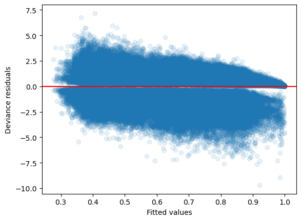

```python
resid = model_weight_variable_section.resid_deviance

plt.scatter(model_weight_variable_section.fittedvalues, resid, alpha=0.1)
plt.axhline(0, color='red')
plt.xlabel("Fitted values")
plt.ylabel("Deviance residuals")
plt.show()
```

**Interpretation**

The residual plot shows that deviance residuals are generally centered around zero, with no strong nonlinear patterns, suggesting that the model is reasonably well specified. However, a slight downward trend is observed as fitted values increase, indicating mild systematic bias where the model may overpredict probabilities at higher fitted values.

```
Cook's D threshold: 6.492874070707399e-06
Number of flagged observations: 63906
```

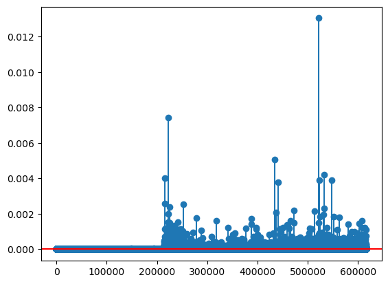

```python
influence = model_weight_variable_section.get_influence(observed=False)
cooks_d = influence.cooks_distance[0]

threshold = 4 / len(trainData)
outliers = cooks_d > threshold

top_5 = cooks_d.argsort()[-5:][::-1]

out = trainData.iloc[top_5].copy()
out['cooks_d'] = cooks_d[top_5]

print("Cook's D threshold:", threshold)
print("Number of flagged observations:", outliers.sum())
out

plt.stem(cooks_d)
plt.axhline(threshold, color='red')
plt.show()
```

```python
#top 5 outliers
top_5=cooks_d.argsort()[-5:][::-1]
out=trainData.iloc[top_5]
out
```

|  | YEAR | PERWT | AGE | fixed_rate_30 | Ownership_Status | Marital_Status | Degree | Employement_Status | Generation_Category | age_group | adjusted_INCTOT | adjusted_MSPUS | age_centered | age_c2 | PERWT_norm |
| --- | --- | --- | --- | --- | --- | --- | --- | --- | --- | --- | --- | --- | --- | --- | --- |
| 521827 | 2020 | 1476.0 | 70 | 3.111698 | 0 | Separated/Divorced | Bachelors Degree | Employed | Boomers | 65+ | 381792.253807 | 397730.565355 | 22.013688 | 484.602447 | 18.595394 |
| 222353 | 2002 | 771.0 | 59 | 6.537308 | 0 | Married | Degrees beyond a bachelors degree | Employed | Pre-Boomer | 56-65 | 524849.299611 | 324369.072957 | 11.013688 | 121.301317 | 9.713448 |
| 434536 | 2015 | 400.0 | 56 | 3.850577 | 0 | Separated/Divorced | Bachelors Degree | Employed | Boomers | 56-65 | 811297.742356 | 389303.802470 | 8.013688 | 64.219191 | 5.039402 |
| 532318 | 2020 | 1556.0 | 77 | 3.111698 | 0 | Separated/Divorced | No college Degree | Unemployed | Pre-Boomer | 65+ | 53329.711643 | 397730.565355 | 29.013688 | 841.794074 | 19.603274 |
| 215368 | 2001 | 2206.0 | 41 | 6.967885 | 0 | Never married | No college Degree | Unemployed | Boomers | 36-45 | 10804.646527 | 306603.985884 | -6.986312 | 48.808559 | 27.792302 |

**Interpretation**

These observations fall within plausible real world ranges and do not appear to be data entry errors. Moreover, the sample size is large and the influential observations do not change the model interpretation, I decided to keep them them in the model.

```python
train_prob = model_weight_variable_section.predict(trainData)
test_prob = model_weight_variable_section.predict(testData)

# I used a threshold of 0.6 to improve classification of non-homeowners,
# since the default 0.5 threshold outputed weaker recall for the non-homeowner class.
train_pred = (train_prob >= 0.6).astype(int)
test_pred = (test_prob >= 0.6).astype(int)
```

```python
from sklearn.metrics import (
    accuracy_score,
    precision_score,
    recall_score,
    f1_score,
    roc_auc_score,
    confusion_matrix,
    classification_report

)

def evaluate_model(y_true, y_prob, y_pred, dataset_name="Dataset"):
    print(f"\n{'='*30}")
    print(f"{dataset_name} Performance")
    print(f"{'='*30}")

    print("Accuracy :", round(accuracy_score(y_true, y_pred), 5))
    print("Precision:", round(precision_score(y_true, y_pred, zero_division=0), 5))
    print("Recall   :", round(recall_score(y_true, y_pred, zero_division=0), 5))
    print("F1 Score :", round(f1_score(y_true, y_pred, zero_division=0), 5))
    print("ROC AUC  :", round(roc_auc_score(y_true, y_prob), 5))
    print("\nConfusion Matrix:")
    print(confusion_matrix(y_true, y_pred))

    print("\nClassification Report:")
    print(classification_report(y_true, y_pred, zero_division=0))



evaluate_model(trainData['Ownership_Status'], train_prob, train_pred, "Train")
evaluate_model(testData['Ownership_Status'], test_prob, test_pred, "Test")
```

```
==============================
Train Performance
==============================
Accuracy : 0.71778
Precision: 0.79777
Recall   : 0.82457
F1 Score : 0.81095
ROC AUC  : 0.71852

Confusion Matrix:
[[ 69285  94530]
 [ 79336 372909]]

Classification Report:
              precision    recall  f1-score   support

           0       0.47      0.42      0.44    163815
           1       0.80      0.82      0.81    452245

    accuracy                           0.72    616060
   macro avg       0.63      0.62      0.63    616060
weighted avg       0.71      0.72      0.71    616060


==============================
Test Performance
==============================
Accuracy : 0.71766
Precision: 0.79883
Recall   : 0.82362
F1 Score : 0.81104
ROC AUC  : 0.7174

Confusion Matrix:
[[17213 23500]
 [19984 93317]]

Classification Report:
              precision    recall  f1-score   support

           0       0.46      0.42      0.44     40713
           1       0.80      0.82      0.81    113301

    accuracy                           0.72    154014
   macro avg       0.63      0.62      0.63    154014
weighted avg       0.71      0.72      0.71    154014
```

**Interpretation**

The model shows moderate predictive performance (ROC AUC = 0.71) and generalizes well on the test set, as indicated by nearly identical performance across training and testing data. It achieves solid performance in identifying homeowners, with high precision (=0.80) and recall (=0.82), resulting in a strong F1 score. For non-homeowners, the model shows lower recall (=.42), indicating that a portion of this group is still misclassified. Overall, the model captures meaningful patterns in the data, but its predictive strength remains stronger for the majority class(1) than for the minority class(0).

```python
import warnings
import statsmodels.api as sm
import statsmodels.formula.api as smf
from sklearn.model_selection import StratifiedKFold
from sklearn.metrics import roc_auc_score, log_loss, brier_score_loss
from scipy.stats import chi2
warnings.filterwarnings('ignore')

FORMULA = (
    'Ownership_Status ~ age_centered + age_c2 + adjusted_INCTOT '
    '+ C(Marital_Status) + C(Degree) + C(Employement_Status) + C(Generation_Category)'
)

N_FOLDS = 5
skf = StratifiedKFold(n_splits=N_FOLDS, shuffle=True, random_state=123)
y = df['Ownership_Status'].values

aucs = []

for fold, (train_idx, test_idx) in enumerate(skf.split(df, y)):
    train_df = df.iloc[train_idx]
    test_df  = df.iloc[test_idx]

    model_cv = smf.glm(
        FORMULA,
        data=train_df,
        family=sm.families.Binomial(),
        var_weights=train_df['PERWT_norm']
    ).fit()

    y_prob = model_cv.predict(test_df)
    y_true = test_df['Ownership_Status'].values

    aucs.append(roc_auc_score(y_true, y_prob))

    print(f"Fold {fold+1}: AUC={aucs[-1]:.4f} ")

print(f"\n--- 5-Fold CV Summary ---")
print(f"AUC:      mean={np.mean(aucs):.4f}  std={np.std(aucs):.4f}")
```

```
Fold 1: AUC=0.7173
Fold 2: AUC=0.7174
Fold 3: AUC=0.7191
Fold 4: AUC=0.7185
Fold 5: AUC=0.7190

--- 5-Fold CV Summary ---
AUC:      mean=0.7183  std=0.0008
```